# feventr quickstart

`feventr` estimates causal effects of events on financial returns. Every estimator consumes the same long panel — unit, date, return, plus treatment assignment and an event date — and returns a common `fes_fit` object.

## Simulated data

The built-in DGP is the two-factor structure from Goldsmith-Pinkham & Lyu’s simulation section: factor loadings drawn around one, daily Fama-French factor realizations, idiosyncratic noise calibrated so half the return variance is systematic, and a one-shot treatment effect on the event day. Selection mechanisms (`"assignment"`, `"timing"`, `"both"`) reproduce the paper’s selection-on-loadings and selection-on-factor-timing designs.

```r
library(feventr)
sim <- simulate_events(n_units = 200, n_pre = 120, n_candidate = 1,
                       n_post = 10, tau = 0.03, seed = 42)
str(sim$events)
```

```
#> 'data.frame':    18 obs. of  2 variables:
#>  $ unit      : chr  "19" "31" "48" "56" ...
#>  $ event_time: num  121 121 121 121 121 121 121 121 121 121 ...
```

## Fitting estimators

One entry point, `event_study()`; the estimator is an argument. `returns` is required — it records whether `ret` holds simple or log returns and selects how cumulative effects compound.

```r
args <- list(data = sim$data, unit = "id", time = "t", ret = "ret",
             treated = sim$events$unit, event_time = sim$event_time,
             window = c(0, 10), est_window = c(-120, -1), returns = "simple")

fit_mean <- do.call(event_study, c(args, list(method = "mean")))
fit_sc   <- do.call(event_study, c(args, list(method = "sc", se = "placebo",
                                              reps = 50, seed = 1)))
fit_sc
```

```
#> feventr fit: method 'sc', 18 treated / 182 donors
#> event window [0, 10], estimation window [-120, -1], returns: simple
#> ATT (avg over window): 0.0035 (se 0.0011)
#> Cumulative effect (compound) at end of window: 0.0379
```

The event-day ATT recovers the simulated 3% effect. `summary()` gives the per-period path; `coef()`, `vcov()`, and `confint()` behave as usual.

```r
head(summary(fit_sc))
```

```
#>   event_time           att          se        car
#> 1          0  0.0316773529 0.003292341 0.03167735
#> 2          1 -0.0034643369 0.002886622 0.02796029
#> 3          2 -0.0002318976 0.002911087 0.02762637
#> 4          3  0.0002216001 0.003073396 0.02785799
#> 5          4  0.0060983941 0.003457094 0.03411654
#> 6          5  0.0026697197 0.003641650 0.03642008
```

Factor-model abnormal returns take the factor series as a data frame keyed on the panel’s time column (excess-return adjustments are the caller’s choice — CAPM means passing excess returns and Mkt-RF):

```r
fit_2f <- do.call(event_study, c(args, list(
  method = "factor", factors = sim$factors[, c("t", "mktrf", "smb")])))
round(fit_2f$att, 4)
```

```
#>       0       1       2       3       4       5       6       7       8       9
#>  0.0325 -0.0020 -0.0001  0.0001  0.0066  0.0023  0.0001 -0.0034  0.0028 -0.0032
#>      10
#>  0.0069
```

## Plots and diagnostics

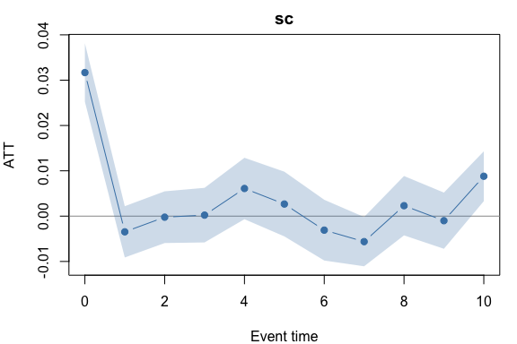

```r
plot(fit_sc)
```

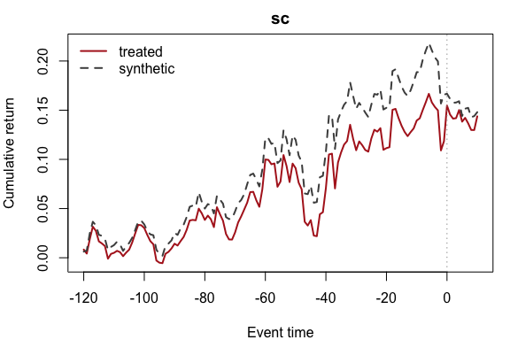

```r
plot(fit_sc, what = "paths")
```

`event_betas()` compares treated, control, and synthetic-control-weighted factor loadings — the paper’s core diagnostic for when simple comparisons mislead:

```r
event_betas(fit_sc, sim$factors[, c("t", "mktrf", "smb")])
```

```
#> Factor loadings over the estimation window (18 treated, 182 control units)
#>                group   stat     alpha mktrf   smb
#>              treated   mean -4.05e-04 0.916 1.023
#>              treated     sd  1.05e-03 0.322 0.338
#>              treated median -1.25e-04 0.931 1.048
#>              control   mean  1.53e-04 1.019 0.944
#>              control     sd  1.09e-03 0.319 0.366
#>              control median  1.50e-04 1.035 0.918
#>  control_weighted_sc   mean -5.64e-05 0.931 0.980
#>  control_weighted_sc     sd        NA    NA    NA
#>  control_weighted_sc median        NA    NA    NA
```

## Many events at once

`event_study_batch()` fits one model per event (each with its own event date, treated units, and donor pool, excluding contaminated donors), in parallel, and reports cross-event averages with cross-event standard errors:

```r
ev <- data.frame(unit = c("1", "2", "10"), event_time = c(80, 80, 100),
                 event = c("a", "a", "b"))
b <- event_study_batch(sim$data, "id", "t", "ret", events = ev,
                       method = "sc", window = c(0, 5),
                       est_window = c(-60, -1), returns = "simple")
b
```

```
#> feventr batch fit: method 'sc', 2/2 events
#> ATT (cross-event avg) at horizon 0: 0.0066 (se 0.0007)
```

```r
summary(b)
```

```
#>   event_time     estimate           se
#> 1          0  0.006566811 0.0006647839
#> 2          1 -0.002224370 0.0098692930
#> 3          2 -0.003551387 0.0090908914
#> 4          3 -0.004883407 0.0040591574
#> 5          4 -0.001492598 0.0015302766
#> 6          5  0.009932119 0.0063603133
```

## The solver

Synthetic control with thousands of donors is the package’s reason to exist: `solve_simplex_ls()` runs Frank-Wolfe (never forming the donor Gram matrix) to find the sparse active donor set, polishes with an exact QP on that support, and verifies optimality with a KKT gradient screen. See the README benchmark table; the solver is exported for direct use:

```r
A <- matrix(rnorm(50 * 200), 50, 200)   # 200 donors, 50 pre-periods
w_true <- c(rep(0.25, 4), rep(0, 196))
b_ <- as.vector(A %*% w_true) + rnorm(50, sd = 0.05)
sol <- solve_simplex_ls(A, b_)
round(head(sort(sol$w, decreasing = TRUE), 6), 3)
```

```
#> [1] 0.240 0.234 0.231 0.226 0.017 0.015
```